# Reproducible Research, Proj 1

cammie partelow

July 13, 2015

This is the r markdown file for the first project in Reproducible Research.

Part 1 Calculate the mean total number of steps taken per day (ignore the missing values):

Calculate the total number of steps taken per day

Make a histogram of the total number of steps taken each day

```r
dset <- read.csv("~/downloads/activity.csv")
```

```r
sumSet <- aggregate(dset$steps, by=list(date=dset$date), FUN=sum, na.rm = TRUE)
# alternate: tapply(dset$steps, dset$date, FUN=sum, na.rm = TRUE)
sumSet
```

```
##          date     x
## 1  2012-10-01     0
## 2  2012-10-02   126
## 3  2012-10-03 11352
## 4  2012-10-04 12116
## 5  2012-10-05 13294
## 6  2012-10-06 15420
## 7  2012-10-07 11015
## 8  2012-10-08     0
## 9  2012-10-09 12811
## 10 2012-10-10  9900
## 11 2012-10-11 10304
## 12 2012-10-12 17382
## 13 2012-10-13 12426
## 14 2012-10-14 15098
```

[output cut: 47 more lines]

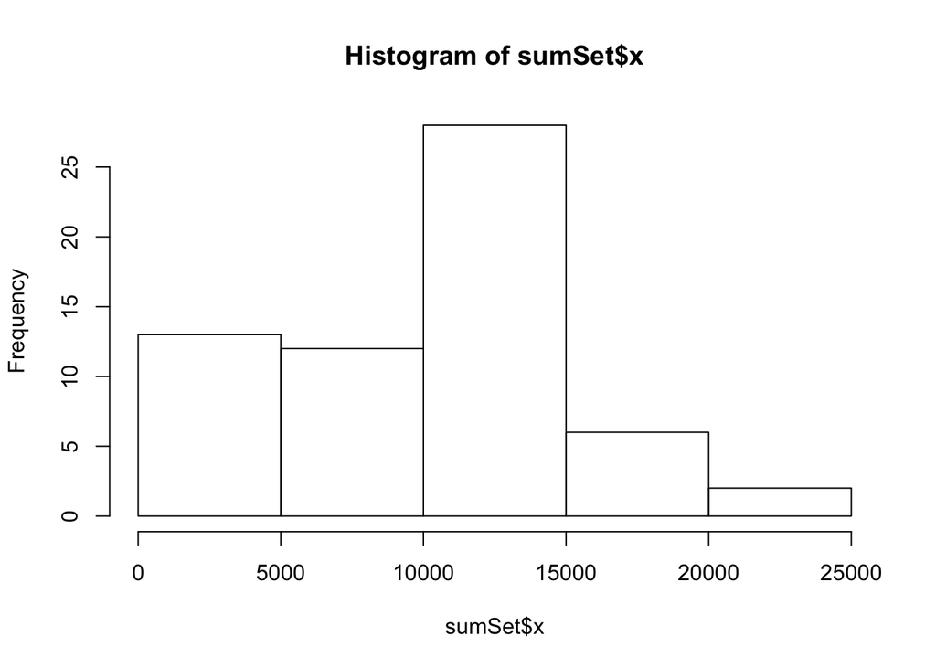

```r
hist(sumSet$x)
```

```r
mean(dset$steps, na.rm = TRUE)
```

```
## [1] 37.3826
```

```r
median(dset$steps, na.rm = TRUE)
```

```
## [1] 0
```

Part 2 Determine average daily activity Make a time series plot (i.e. type = “l”) of the 5-minute interval (x-axis) and the average number of steps taken, averaged across all days (y-axis)

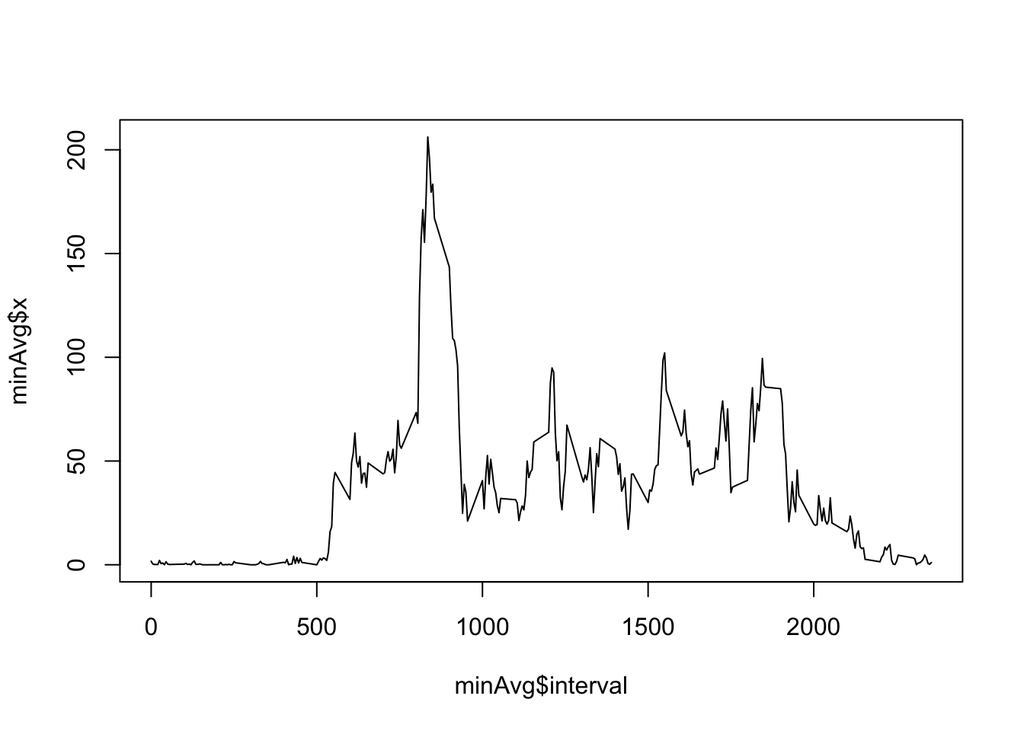

Which 5-minute interval, on average across all the days in the dataset, contains the maximum number of steps? not the best method, revisit when have internet/time

```r
minAvgMax <- max(minAvg$x)
subset(minAvg, minAvg$x >= minAvgMax, select = c(interval, x))
```

```
##     interval        x
## 104      835 206.1698
```

Part 3 Inputting Data Calculate and report the total number of missing values in the dataset (i.e. the total number of rows with NAs)

```r
library(plyr)
naSet <- subset(dset, is.na(dset$steps))
count(naSet[,1])
```

```
##    x freq
## 1 NA 2304
```

Create a new dataset that is equal to the original dataset but with the missing data filled in.

```r
fillSet <- dset
fillSet$steps[is.na(fillSet$steps)] <- minAvg$x[match(fillSet$interval,minAvg$interval)][is.na(fillSet$steps)]
```

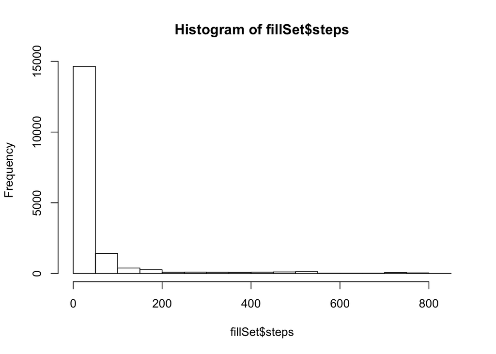

```r
hist(fillSet$steps)
```

Part 4 Activity pattern differences on weekdays and weekends? For this part the weekdays() function may be of some help here. Use the dataset with the filled-in missing values for this part.

Create a new factor variable in the dataset with two levels – “weekday” and “weekend” indicating whether a given date is a weekday or weekend day.

```r
fillWeek <- data.frame(steps = fillSet$steps, interval = fillSet$interval, dow = ifelse(weekdays(as.Date(fillSet$date)) %in% c("Saturday", "Sunday"), "Weekend", "Weekday"))
```

Make a panel plot containing a time series plot (i.e. type = “l”) of the 5-minute interval (x-axis) and the average number of steps taken, averaged across all weekday days or weekend days (y-axis). See the README file in the GitHub repository to see an example of what this plot should look like using simulated data.

[figure not shown]